# Exploratory Analysis

## The Effects of Covid on University Student’s Mental Health

### Authors

Kelly Chen, James Moy, Sadeem Alselmi, Khadija Dial

### Date

Winter 2022

### Abstract

Students are one of the groups of people whose mental health and wellbeing was affected by the Covid-19 pandemic, and the effects are both long-term and short-term, with some coping better than others. This study will investigate the long-term and short-term impacts of the Covid-19 pandemic on students, and the relationship between the demographic factors of students and their mental health during the pandemic. The study will also focus on coping mechanisms of students, external factors that enabled them to cope, and individual factors that influenced the effects of the pandemic upon the students.

### Keywords

*Coronavirus, mental health, stress, demographic factors, coping mechanisms*

### Introduction

1. What are the short-term effects of corona-virus on the mental-health of students?
2. What are long-term effects of corona-virus on the mental-health of students?
3. What are some coping mechanisms used by students to cope with mental health during the pandemic?
4. What are some demographic factors that influenced the impacts of the pandemic on the mental health of students?
5. What external factors influenced the impact of the pandemic on the mental health of students?

These questions are important in disaster preparedness in the case of such pandemics or situations in the future. Most students were in the middle of their studies at various levels, and this could have increased the stress especially for those not near their relatives, or those whose relatives or friends contracted the disease and even succumbed to it. The situation was worsened by the lock-down which created a distance barrier, and which also reduced the number of activities that students could engage in to improve their well-being, and mental health. Students are a vulnerable group as it relates to mental health because they are already experiencing other stressors. This study seeks to identify ways that students can be shielded from excessive stressors, and identify effective support that can be used to enhance their mental health and wellbeing in the event of such events.

### Related Work

Sources Used:

[SWLS - Satisfaction with Life screening](https://fetzer.org/sites/default/files/images/stories/pdf/selfmeasures/SATISFACTION-SatisfactionWithLife.pdf)

[GAD-7 - General Anxiety Disorder](https://web.p.ebscohost.com/ehost/detail/detail?vid=0&sid=6e304060-b7f0-47ea-9428-efaf6f778ee9%40redis&bdata=JnNpdGU9ZWhvc3QtbGl2ZQ%3d%3d#AN=161465690&db=a9h)

PSS-10 - Perceived Stress Screening

[PHQ-9 - The Patient Health Questionnaire](https://www.ncbi.nlm.nih.gov/pmc/articles/PMC1495268/) , [A similar study](https://pubmed.ncbi.nlm.nih.gov/32897868/)

Our topic is on the well-being and mental health status of university students during the COVID-19 pandemic. In order to better understand the effects of the pandemic on the mental health of university students, we have done further research to get a deeper understanding of some of the screenings used within the dataset we chose. Some of the screening used are the PSS-10 (Perceived Stress screening), GAD-7 (Generalized Anxiety Disorder scale), PHQ-9, SWLS (Life Satisfaction screening) and others. The Perceived Stress Scale (PSS-10) is a widely used instrument to measure individuals’ appraisal of global stress in academic research and clinical practice. This scale operates based on two major factors, perceived helplessness and perceived self-efficacy. “Perceived helplessness is made of negatively phrased items “In the last month, how often have you felt nervous and stressed”, while perceived self-efficacy is made of positively phrased items such as, “In the last month, how often have you felt that things were going your way” (Liu Xi, et.al). In combination with the PSS-10, the GAD-7 and PHQ-9 screenings were also utilized. Just like the PSS-10, the GAD-7 and PHQ-9 are other examples of self-report scales used for the screening, diagnosis, and severity assessment of various factors of mental health. The PHQ-9 is used for diagnosing common mental disorders, while the GAD-7 is used for the assessment of anxiety severity. Lastly, the SWLS or satisfaction with life screening assesses an individual’s satisfaction with their life as a whole. In the “Review of the Satisfaction with Life Scale” by Pavot, W. G., & Diener, E. they emphasize that the scale does not assess satisfaction with life domains such as health or finances. Because such domains are subject to change depending on the individual, the authors state that the screening rather, “allows subjects to integrate and weight these domains in whatever way they choose.” (Pavot, et. al). Using these screenings together within the dataset allows for us to draw more insightful connections, as well as highlight the need to develop preventive strategies to address the mental health of college students.

### The Dataset

The dataset our group has selected is from Mendeley data: [“Mental health and well-being of university students during the fourth wave of the COVID-19 pandemic”](https://data.mendeley.com/datasets/bvcwx4tfjm). The contributor for this dataset is Aleksandra Rogowska and the institution of Uniwersytet Opolski Instytut Psychologii. The data was collected from university students from Poland and was done through an online survey. In the survey, information was collected on the student’s demographic and identity. Next, the survey and their research wanted to assess the mental and physical health of these students during the fourth wave of the COVID-19 pandemic. In addition, the student’s vaccination status was also investigated to provide a comparison on the relationship between vaccination and well-being. Alongside this were questions regarding exposure to the coronavirus. There are 706 observations or students assessed (rows) and 78 features (columns).

When working with this data we need to address the bias that surrounds vaccinations and the COVID-19 pandemic. In the United States, we have seen the nation divided on what is right for our health. Some people believe that the vaccine is not safe while others view the vaccine as a necessity to protect themselves and others. This study was conducted in Poland, which we are unfamiliar with. The data might be skewed in favor of or against vaccination. In addition, there are many factors to consider for a student’s well being. The data does not address the student’s income or financial status, living conditions, or view on vaccinations.

### Implications

The findings from data about students’ mental health during the Covid-19 pandemic may have significant implications for technologists, designers, and policymakers in how they orient their future projects and the scope they take to address certain issues. Technologists may need to design new remote tools and technologies that can better support students’ mental health across distances, such as virtual counseling or self-care apps. Designers may need to consider the impact of their work on students’ mental well-being, especially in regards to screen time and social media use. Policymakers may need to provide funding for mental health support in schools and to ensure that privacy laws are in place to protect students’ mental health data. They may also need to consider the long-term impact of the pandemic on students’ mental health and plan for future support to make up for lost time.

### Limitations & Challenges

The limitations to this study are that 706 university students exclusively from Poland were surveyed. The data collected from this dataset can only be used for a subset of this population that fit the same environmental and cultural influences. It is also unknown how the specific surveys were conducted or how the researchers ensured that the data was random. We cannot be 100% confident that the dataset is a true representation of the population. A second possible limitation is that the data was collected across the span of just one month. This short timespan may not be entirely representative of the entire effect of the pandemic on the wellbeing of students. Additionally, the time that the surveys were conducted may coincide with additional academic stressors such as final exams or impactful school-wide events. Some additional challenges to this dataset are that prior moderate to severe levels of depression may have already existed in the subjects sampled which may have skewed any conclusions about the data. In addition, the relationship between vaccination status and levels of mental health remain ambiguous as the simple fact that an individual has a vaccine is not indicative of their overall mental stability and happiness.

### Summary Information

```
## # A tibble: 2 × 4
##   Vaccination count avg_age avg_wellbeing
##         <dbl> <int>   <dbl>         <dbl>
## 1           0   149    22.2          22.4
## 2           1   557    23.1          20.8
```

```
## Summary Information
```

```
## Dataset Description:
```

[output not shown]

```
## Potential Biases:
```

```
## The data might be skewed in favor of or against vaccination. In addition, the data does not address the students' income or financial status, living conditions, or views on vaccinations.
```

```
## Summary Statistics by Vaccination Status:
```

```
## The table below shows the number of students, their average age, and their average wellbeing score, grouped by vaccination status. The values are rounded to one decimal place (for age) and two decimal places (for wellbeing score).
```

[output not shown]

The first code written for our summary information R script summarizes the data by vaccination status and calculates the number of students, the average age, and the average well-being score for each group. The table generated from this code provides information about the relationships between vaccination status, age, and well-being among the sample, which can help identify potential patterns or differences in the data.

### Table

```
## # A tibble: 6 × 10
##   Gender num_s…¹ num_f…² perce…³ perce…⁴ perce…⁵ perce…⁶ perce…⁷ avg_h…⁸ perce…⁹
##   <chr>    <int>   <int>   <dbl>   <dbl>   <dbl>   <dbl>   <dbl>   <dbl>   <dbl>
## 1 Women      539      78       0       0       0       0       0    21.2       0
## 2 Men        146      78       0       0       0       0       0    20.7       0
## 3 Agend…      18      78       0       0       0       0       0    19.8       0
## 4 Domin…       1      78       0       0       0       0       0    26         0
## 5 Tomasz       1      78       0       0       0       0       0    26         0
## 6 non-b…       1      78       0       0       0       0       0    20         0
## # … with abbreviated variable names ¹num_students_assessed, ²num_features,
## #   ³percent_vaccinated, ⁴percent_covid_symptoms, ⁵percent_anxiety,
## #   ⁶percent_depression, ⁷percent_anx_dep, ⁸avg_hours_of_sleep,
## #   ⁹percent_supported
```

```
## # A tibble: 6 × 4
##   Gender     num_students_assessed percent_vaccinated avg_hours_of_sleep
##   <chr>                      <int>              <dbl>              <dbl>
## 1 Women                        539                  0               21.2
## 2 Men                          146                  0               20.7
## 3 Agender                       18                  0               19.8
## 4 Dominik                        1                  0               26
## 5 Tomasz                         1                  0               26
## 6 non-binary                     1                  0               20
```

### Chart 1

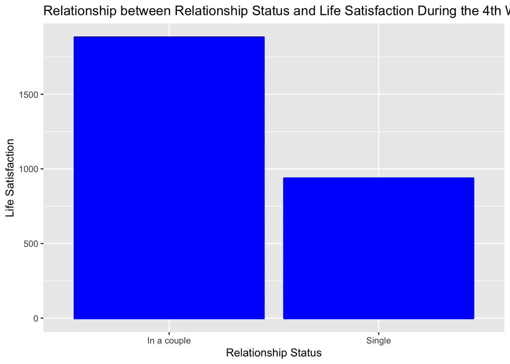

### Chart 2

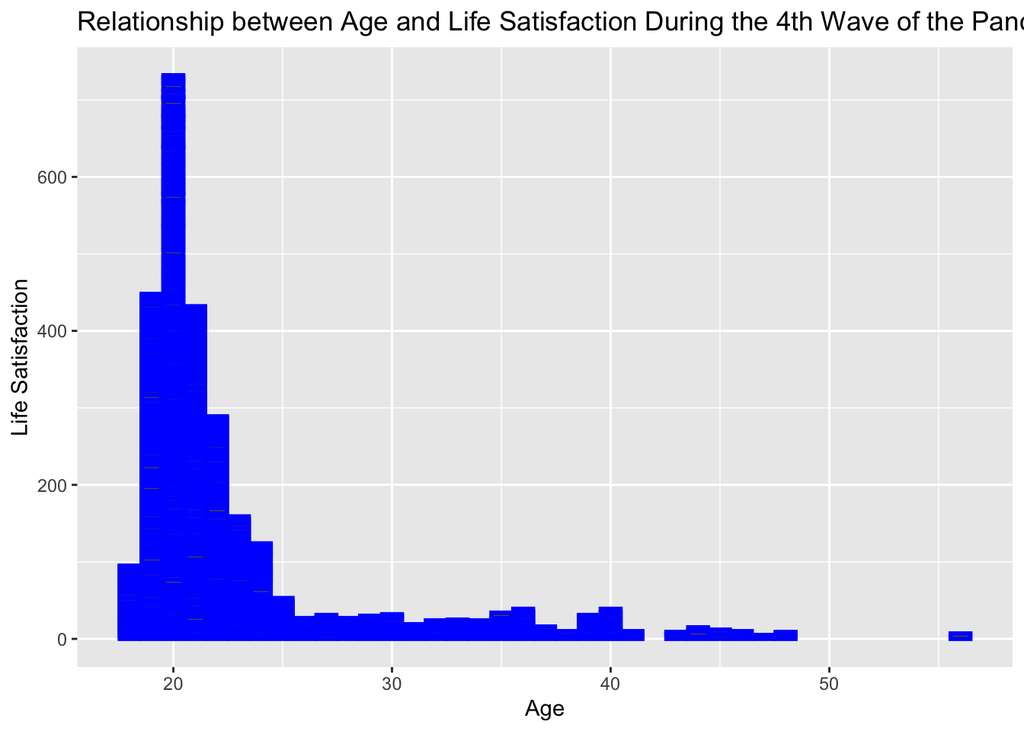

Chart 2 depicts the relationship between age and self-prescribed overall life satisfaction on a ranking from -10 with 1 being the lowest score of overall life satisfaction and 10 being the highest. We chose these two variables because we are measuring the affects of multiple factors as they impact life satisfaction. Age is a particular interesting variable because maturity and needs for social interaction are different depending on the time of life of many individuals and may correlate to life satisfaction and happiness. From the distribution of scores we can see that ages 18-23 recorded the greatest sum of ratings as compared to any other age range. This data may be skewed for a number of reasons, but one may be that that more individuals in the 18-23 range were interviewed which allowed for a much greater sum of total rankings of life satisfaction.

### Chart 3

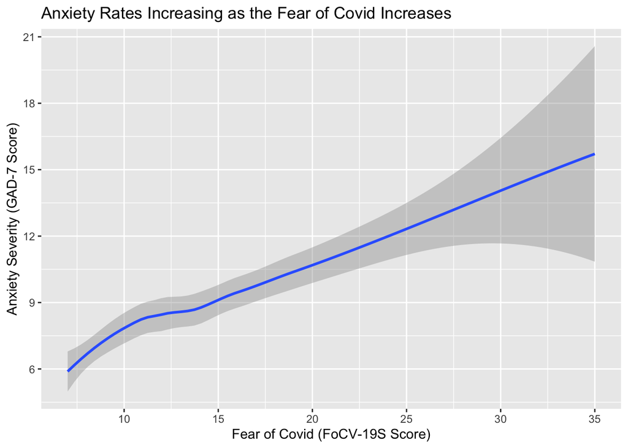

It is also important to note that this dataset was collected from university students in Poland so we cannot immediately generalize these finding to university students in the US.